# Aula 2 - Semana 1

Ivanildo Batista

9 de fevereiro de 2021

## Curso Financial Risk Management with R - Semana 1

### Calculating Daily Returns (Aula 2)

O objetivo dessa aula e calcular os retornos diarios do indice WILSHIRE 5000, que foi extraido na aula anterior.

O calculo de retorno e realizado dividindo o valor atual do indice pelo valor do dia anterior e subtraindo 1 (um), conforme abaixo
$$ret_t = \frac{wilsh_t}{wilsh_{t-1}} - 1$$
Os resultados podem ser negativos e positivos, mas ha uma limitacao. Os valores negativos nao podem ser menores que -1 (menos um), ou seja, a variacao do valor do indice de um dia para o outro nao pode ser menor que -100%, mas os resultados positivo da variacao podem ultrapassar os 100%. Isso nao apresenta resultados simetrico, por isso e melhor utilizar o logaritmo desse resultado.

Para usar o logaritmo soma-se 1 ao valor da variacao do indice (todos os valores) e depois tiramos o logaritmo (tambem podemos pegar o logaritmo do dia atual menos o logaritmo do dia anterior) e, por fim, encontramos o valor do retorno invertendo o logaritmo com a funcao exponencial. Abaixo podemos ver como e feito esse calculo:

$$logret_t = log(1+ret_t)$$
ou
$$logret_t = log(wilsh_t) - log(wilsh_{t-1})$$

Antes irei realizar todos os procedimentos da aula anterior.

```r
library(quantmod)
wilsh = getSymbols("WILL5000IND", src = "FRED", auto.assign = FALSE)
```

[output not shown]

```r
wilsh = na.omit(wilsh)
wilsh = wilsh['1979-12-31/2017-12-31']
names(wilsh) = "TR"
```

**Calculando o retorno**

```r
logret  = diff(log(wilsh$TR))
head(logret,3)
```

```
##                     TR
## 1979-12-31          NA
## 1980-01-02 -0.02127740
## 1980-01-04  0.01069529
```

Verificando se ha valores faltantes:

```r
sum(is.na(logret))
```

```
## [1] 1
```

Removendo o valor faltante:

```r
logret = diff(log(wilsh$TR))[-1]
round(head(logret,3),6)
```

```
##                   TR
## 1980-01-02 -0.021277
## 1980-01-04  0.010695
## 1980-01-07  0.005305
```

Agora, vemos que nao ha valores faltantes.

```r
sum(is.na(logret))
```

```
## [1] 0
```

Plotando os retornos logaritmicos diarios:

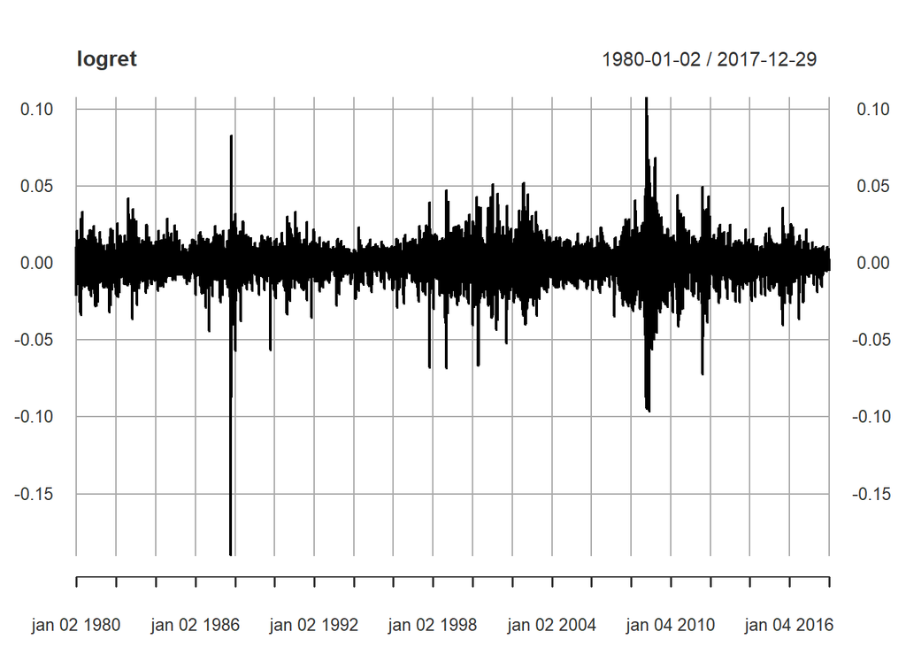

```r
plot(logret)
```

Encontrando o retorno do logaritmo do retorno

```r
ret = exp(logret) - 1
round(head(ret,3),6)
```

```
##                   TR
## 1980-01-02 -0.021053
## 1980-01-04  0.010753
## 1980-01-07  0.005319
```

Plotando o grafico dos retornos diarios

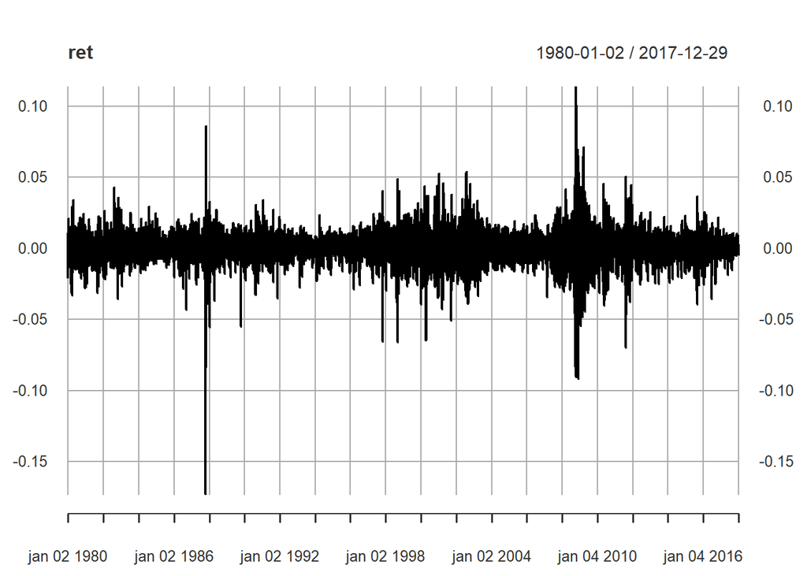

```r
plot(ret)
```